Plotting chromosomes II Fernando Roa 23 08 2019

[figure not shown]

# 2 Plotting chromosomes II

This guide shows the files to plot idiograms of karyotypes of holocentrics and optionally marks.

## 2.1 Load package

visit gitlab for installation instructions https://gitlab.com/ferroao/idiogramFISH

```r
#load package
library(idiogramFISH)
```

## 2.2 Get your chromosome size data

Initially you have to put your chromosome data in a data.frame.

### From scratch:

```r
# Example data.frame written in R, use: (column OTU is optional if only 1 OTU)
mydfChrSizeHolo<-read.table(text=
"            OTU chrName chrSize
\"Species one\"   1     6.5
\"Species one\"   2     5.0
\"Species one\"   3     4.0
\"Species one\"   4     4.0
\"Species one\"   X     3.0    "  ,  header=TRUE, stringsAsFactors=FALSE,fill=TRUE)
```

| OTU | chrName | chrSize |
| --- | --- | --- |
| Species one | 1 | 6.5 |
| Species one | 2 | 5.0 |
| Species one | 3 | 4.0 |
| Species one | 4 | 4.0 |
| Species one | X | 3.0 |

### or loading saved data:

If you use RStudio, in menu “Session”, open “Set working directory” for choosing your desired folder or:

```r
setwd("~/folder/subfolder")
```

Open your chromosome data as data.frame importing it from a .csv (read.csv) or .xls file (readxl).

```r
mydfChrSize<-read.csv("somefile.csv")
```

For fixing column names use:

```r
colnames(mydfChrSize)<-c("OTU", "chrName","chrSize")
```

top

## 2.3 Get marks general data

This data.frame is optional for ver. > 1.0.0

```r
packageVersion("idiogramFISH")
```

Put your mark data in a data.frame. This data.frame has the marks present in all karyotypes without position info. If the `style` column is not present, param. `defaultStyleMark = "square"` will be used during plotting.

```r
# From scratch:
mydfMarkColor<-read.table(text=
"  markName markColor  style
1       5S       red   dots
2      45S     green square
3     DAPI      blue square
4      CMA    yellow square"  ,  header=TRUE, stringsAsFactors=FALSE,fill=TRUE)
```

| markName | markColor | style |
| --- | --- | --- |
| 5S | red | dots |
| 45S | green | square |
| DAPI | blue | square |
| CMA | yellow | square |

For fixing column names use:

```r
colnames(mydfMarkColor)<-c("markName", "markColor","style")
# if style column not present it will be filled with "square"
```

top

## 2.4 Get marks positions data

Open or write your mark positions in a data.frame. This data.frame has the marks present in all karyotypes with position info.

```r
# We will use column OTU if data.frame because chromosome size df has it
mydfMarkPosHolo<-read.table(text=
"             OTU  chrName markName markPos markSize chrRegion
\"Species one\"       4        B      NA       NA        w           # whole chromosome mark, use 'w' in col. chrRegion
\"Species one\"       3     DAPI     2.0      0.5
\"Species one\"       1      45S     2.0      0.5
\"Species one\"       2     DAPI     2.0      0.5
\"Species one\"       X      CMA     2.0      0.5
\"Species one\"       X       5S     0.5      0.5
\"Species one\"       X       5S     0.5      0.5"  ,  header=TRUE, stringsAsFactors=FALSE,fill=TRUE)
```

| OTU | chrName | markName | markPos | markSize | chrRegion |
| --- | --- | --- | --- | --- | --- |
| Species one | 4 | B | NA | NA | w |
| Species one | 3 | DAPI | 2.0 | 0.5 |  |
| Species one | 1 | 45S | 2.0 | 0.5 |  |
| Species one | 2 | DAPI | 2.0 | 0.5 |  |
| Species one | X | CMA | 2.0 | 0.5 |  |
| Species one | X | 5S | 0.5 | 0.5 |  |
| Species one | X | 5S | 0.5 | 0.5 |  |

For fixing column names use something like:

```r
colnames(mydfMarkColor)<-c("OTU", "chrName","markName","markPos","markSize")
```

top

## 2.5 Plotting

function `plotIdiogramsHolo` deprecated after ver. > 1.5.1

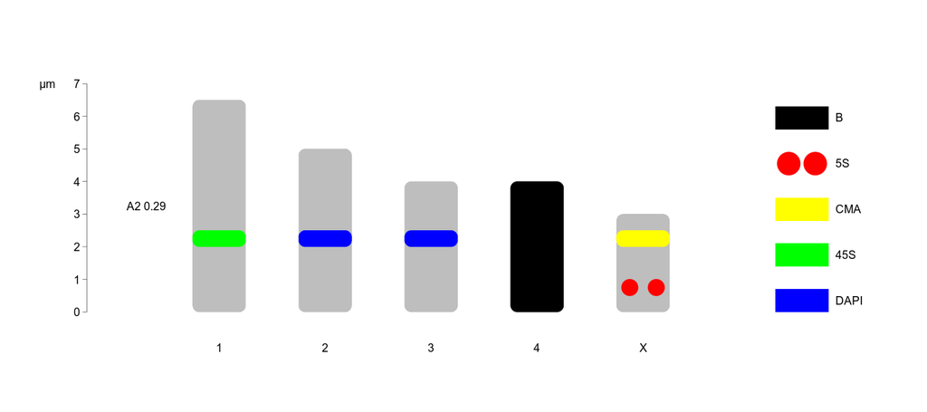

```r
# library(idiogramFISH)
# svg("mydfChrSizeHolo.svg",width=13.5,height=6 )
# png("mydChrSizeHolo.png", width=600, height=300)
par(mar=c(0,4,0,1)) # bottom left top right

# function `plotIdiogramsHolo` deprecated after ver. > 1.5.1

plotIdiograms(dfChrSize  = mydfChrSizeHolo,# data.frame of chr. sizes
              dfMarkColor= mydfMarkColor,  # df of mark style
              dfMarkPos  = mydfMarkPosHolo,# df of mark positions
              addOTUName=FALSE,            # add OTU names

              xlimLeftMod= 1,              # modify xlim left argument
              ylimTopMod= -1,              # modify ylim top argument
              ylimBotMod= -2               # modify ylim bottom argument
              ,rulerPos = 0
              ,ruler.tck = -0.01

              ,legendWidth=1               # width of legend
              ,legendHeight=.7             # height of legend item
              #,asp=1                      # y x aspect
)
```

```r
# dev.off() # closes png or svg
```

It is not mandatory to use `dfMarkColor` and you can also use the parameter `mycolors` (optional too), to establish marks’ colors. When using `mycolors`, colors are assigned depending on the order of marks, i.e.:

```r
unique(dfMarkPosHolo$markName)
```

[output not shown]

```r
# par(mar=c(1,4,1,1))
par(mar=rep(0,4))

plotIdiograms(dfChrSize = dfChrSizeHolo, # d.f. of chr. size
              dfMarkPos  = dfMarkPosHolo, # d.f. of marks' positions
              mycolors   = c("green","yellow","blue","red"),  # colors for marks

              addOTUName=FALSE,           # do not add OTU name
              ruler=FALSE,                # do not add ruler
              xlimLeftMod=1,              # modify left xlim arg.
              xlimRightMod=3,             # modify right xlim arg.
              ylimBotMod=.2               # modify bottom ylim
)
```

[output not shown]

top

## 2.6 Example with several species (OTUs)

To illustrate this, we will load some data.frames from the package

- Chromosome sizes

```r
data(bigdfChrSizeHolo)
```

| OTU | chrName | chrSize |
| --- | --- | --- |
| species one | 1 | 5.1 |
| species one | 2 | 5.0 |
| species one | 3 | 4.9 |
| species one | 4 | 5.2 |
| species two | 1 | 3.0 |
| species two | 2 | 4.0 |
| species two | 3 | 2.0 |
| species two | 4 | 5.0 |
| species three | 1 | 1.5 |
| species three | 2 | 2.0 |
| species three | 3 | 6.0 |
| species three | 4 | 8.0 |

- Mark characteristics, does not require OTU
- d.f optional for ver. > 1.0.0

```r
data(dfMarkColor)
```

| markName | markColor | style |
| --- | --- | --- |
| 5S | red | dots |
| 45S | green | square |
| DAPI | blue | square |
| CMA | yellow | square |

- Mark position

```r
data(bigdfMarkPosHolo)
```

| OTU | chrName | markName | markPos | markSize |
| --- | --- | --- | --- | --- |
| species two | 3 | 5S | 1.0 | 0.5 |
| species two | 3 | DAPI | 2.0 | 0.5 |
| species two | 1 | 45S | 2.0 | 0.5 |
| species two | 2 | DAPI | 2.0 | 0.5 |
| species two | 4 | CMA | 2.0 | 0.5 |
| species two | 4 | 5S | 0.5 | 0.5 |

### 2.6.1 Plotting

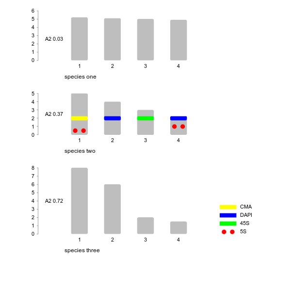

```r
library(idiogramFISH)

# fig.width=6, fig.height=6
png("bigdfChrSizeHolo.png", width=600, height=600)
# par(mar=c(1,1,1,1))
par(mar=rep(0,4))

plotIdiograms(dfChrSize=bigdfChrSizeHolo, # chr. size data.frame
              dfMarkColor=dfMarkColor,    # df of mark style
              dfMarkPos=bigdfMarkPosHolo, # df of marks' position

              markDistType="cen",         # measure towards center of mark
              roundness=6,                # vertices roundness of chr. and marks

              karHeiSpace = 4,            # karyotype height including spacing
              karSepar=TRUE,              # reduce vertical space among karyotypes
              amoSepar = 1,               # separation among karyotypes
              distTextChr=.5,             # distance text to chr.

              legendWidth = 1             # width of legend labels

              ,chrId="simple",            # numbering of chr., not using "original" name

              indexIdTextSize=.9,         # font size of chr names and indices
              markLabelSize=.9,           # font size of legends

              rulerPos=0,
              rulerNumberSize=.9,         # font size of ruler
              ruler.tck= -.004,           # tick length and orient.

              ylimBotMod=.4               # modify ylim bottom argument
              #,asp=1                     # y x aspect
)
dev.off()
```

top

## 2.7 Using bases instead of micrometers

Create some data in millions of bases:

```r
# transform previous data.frames for simplicity
bigdfChrSizeHoloMb <- bigdfChrSizeHolo
bigdfChrSizeHoloMb$chrSize <- bigdfChrSizeHoloMb$chrSize * 98000000
bigdfMarkPosHoloMb <- bigdfMarkPosHolo
bigdfMarkPosHoloMb$markPos <- bigdfMarkPosHoloMb$markPos * 98000000
bigdfMarkPosHoloMb$markSize<- bigdfMarkPosHoloMb$markSize * 98000000
```

### Plotting

In the plot length is shown in Mb

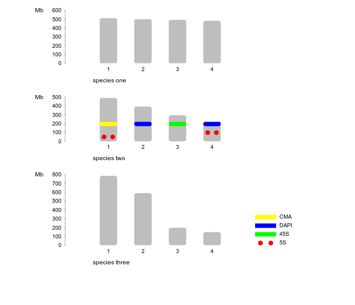

```r
png("bigdfChrSizeHolo2.png", width=700, height=600)
# par(mar=c(1,1,1,1))
par(mar=rep(0,4))

plotIdiograms(dfChrSize=bigdfChrSizeHoloMb,  # chr. size data.frame
              dfMarkColor=dfMarkColor,       # df of mark style
              dfMarkPos=bigdfMarkPosHoloMb,  # df of mark positions

              markDistType="cen",            # distance to mark is to its center
              roundness=4,                   # vertices roundness of chr. and marks
              distTextChr = .5,              # separ. chr. to text

              karHeight = 2,                 # rel. karyotype height
              karHeiSpace = 4,               # karyotype height including spacing
              karSepar=TRUE,                 # reduce spacing among karyotypes
              amoSepar = 1,                  # depends on karSepar, amount of sep.

              chrId="simple",                # chr. names not "original"
              indexIdTextSize=.9,            # font size of chr names and indices
              karIndex = FALSE,              # do not add karyotype asymmetry index

              rulerNumberSize=.9,            # font size of ruler
              rulerPos = 0,                  # position of ruler
              ruler.tck= -.004,              # ruler tick length and orient.
              ylabline = -6, # <- NEW        # modifies position of ruler title (Mb)

              markLabelSize=.9,              # font size of legend
              legendWidth = 1.2,             # width of legends

              xlimLeftMod = 1,               # modify left argument of xlim
              ylimBotMod=.4                  # modify bottom argument of ylim
              # ,asp=1                       # y x aspect
              )
dev.off()
```

For another example see: https://stackoverflow.com/questions/33727432/how-to-plot-positions-along-a-chromosome-graphic/57153497#57153497

top

## 2.8 GISH of holocentric chromosomes

You need the data.frame of chr. sizes, and a d.f. of marks

### Chr. sizes:

```
parentalAndHybHoloChrSize
```

| OTU | chrName | chrSize |
| --- | --- | --- |
| Parental 1 | 7 | 4 |
| Parental 1 | 4 | 2 |
| Parental 1 | 5 | 6 |
| Parental 1 | 6 | 7 |
| Parental 2 | 1 | 4 |
| Parental 2 | 2 | 5 |
| Parental 2 | 3 | 3 |
| Allopolyploid | 7 | 4 |
| Allopolyploid | 2 | 5 |
| Allopolyploid | 3 | 3 |
| Allopolyploid | 4 | 2 |
| Allopolyploid | 5 | 6 |
| Allopolyploid | 6 | 7 |

### Marks’ positions data

```
dfAlloParentMarksHolo
```

|  | OTU | chrName | markName | chrRegion |
| --- | --- | --- | --- | --- |
| 1 | Allopolyploid | 7 | Parental 1 | w |
| 4 | Allopolyploid | 2 | Parental 2 | w |
| 5 | Allopolyploid | 3 | Parental 2 | w |
| 6 | Allopolyploid | 4 | Parental 1 | w |
| 7 | Allopolyploid | 5 | Parental 1 | w |
| 8 | Allopolyploid | 6 | Parental 1 | w |
| 9 | Parental 1 | 6 | Parental 1 | w |
| 10 | Parental 1 | 5 | Parental 1 | w |
| 11 | Parental 1 | 7 | Parental 1 | w |
| 12 | Parental 1 | 4 | Parental 1 | w |
| 13 | Parental 2 | 2 | Parental 2 | w |
| 14 | Parental 2 | 1 | Parental 2 | w |
| 15 | Parental 2 | 3 | Parental 2 | w |

### Plotting

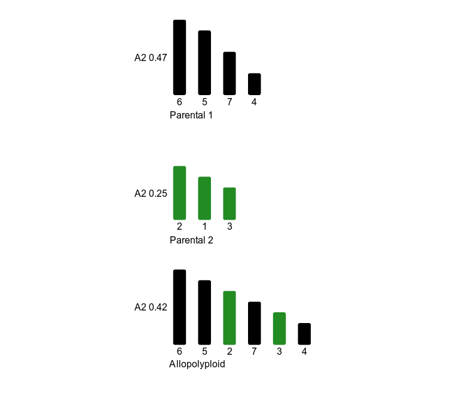

```r
# svg("gish.svg",width=8,height=7 )
par(mar=c(0,0,0,0))
plotIdiograms(dfChrSize = parentalAndHybHoloChrSize,  # d.f. of chr. sizes
              dfMarkPos = dfAlloParentMarksHolo,      # d.f. of marks' positions
              chrColor  = "gray",          # chr. color
              cenColor  = NULL,            # cen. color when GISH

              karHeight = 3,               # karyotype height without spacing
              karHeiSpace=5,               # karyotype height including spacing
              distTextChr = 0.8            # separation among chr. and text

              ,ruler=FALSE                 # no ruler
              ,legend=""                   # no legend

              ,xlimRightMod = 0            # xlim right arg. modif.
              #,asp=1                      # y x aspect
)
```

```r
# dev.off()
```

top

## 2.9 Holocentrics in groups

Let’s modify some data.frames to add a group

```r
data("dfChrSizeHolo")
data("dfMarkPosHolo")
dfMarkPosHoloHetero<-dfMarkPosHolo
dfMarkPosHoloHetero$chrName<-c(3,3,"1A",2,"1B","1B")
dfMarkPosHoloHetero$OTU<-"heteromorphic"

dfChrSizeHoloHetero<-dfChrSizeHolo
dfChrSizeHoloHetero$chrName<-c("1A","1B",2,3)
dfChrSizeHoloHetero$OTU<-"heteromorphic"

# Adding the group column
dfChrSizeHoloHetero$group<-c(1,1,NA,NA)
```

### Creating a new data.frame for holocentrics

```r
dfChrSizeHoloGroup<-data.frame(OTU="Species name",
                               chrName=c(1,1,1,1,2,3,4),
                               chrSize=c(3.1,3.2,3.3,3.4,4,5,6),
                               group=c(1,1,1,1,NA,NA,NA)
                               )
```

| OTU | chrName | chrSize | group |
| --- | --- | --- | --- |
| Species name | 1 | 3.1 | 1 |
| Species name | 1 | 3.2 | 1 |
| Species name | 1 | 3.3 | 1 |
| Species name | 1 | 3.4 | 1 |
| Species name | 2 | 4.0 | NA |
| Species name | 3 | 5.0 | NA |
| Species name | 4 | 6.0 | NA |

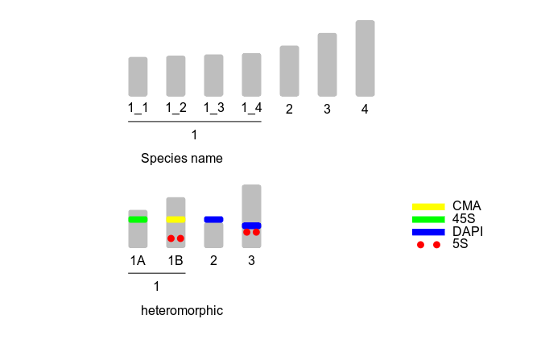

```r
par(mar=rep(0,4))
mergedChrSize<-plyr::rbind.fill(dfChrSizeHoloGroup,dfChrSizeHoloHetero)

plotIdiograms(dfChrSize=mergedChrSize,      # data.frame of chr. sizes
              dfMarkPos=dfMarkPosHoloHetero,# d.f. of marks
              orderBySize = FALSE,          # do not order chr. by size
              karIndex = FALSE,             # do not add karyotype indices
              addOTUName = TRUE,            # add OTU name
              karHeiSpace = 4,              # height of kar. with spacing

              ruler=FALSE,                  # no ruler

              xlimLeftMod=-1,               # modify left argument of xlim
              xlimRightMod=0,               # modify right argument of xlim
              ylimBotMod=1.3                # modify bottom argument of ylim
)
```